# Differential gene expression upon GSK3 inhibitor treatment

Benedikt Rauscher

11/24/2020

# Dependencies

```r
library(affy)
library(limma)
library(clusterProfiler)
library(ReactomePA)
library(enrichplot)
library(org.Hs.eg.db)
library(pheatmap)
library(reshape2)
library(tidyverse)
library(cowplot)
library(here)
```

Define function namespace.

```r
filter <- dplyr::filter
select <- dplyr::select
rename <- dplyr::rename
slice <- dplyr::slice
```

Set parameters for plotting.

```r
theme_set(theme_cowplot())
```

# Data loading and normalization

We load the gene expression data from the raw Affymetrix CEL files and normalize the data using RMA.

```r
## list of cel files
cel_files <- list.files(here('../../data/gene_expression/gsk3_inhibitor/cel_files/'),
                        full.names = T, pattern = '.CEL')

## parse and normalize
affy_batch <- ReadAffy(filenames = cel_files)
expr_mat <- expresso(
  affy_batch,
  bgcorrect.method = 'rma',
  normalize.method = 'quantiles',
  pmcorrect.method = 'pmonly',
  summary.method = 'avgdiff'
)
expr_mat <- log(exprs(expr_mat))

## create an annotation for the samples
sample_info <- tibble(names = colnames(expr_mat)) %>%
  extract(names, c('line', 'treatment', 'rep'),
          regex = '^(D.+?)-(.+?)-([1,2])_.+?', remove = F)

## create an annotation for the probe IDs
load(here('../../data/gene_expression/promise_expr.rda'))
probe_anno <- promise_expr %>% distinct(probe, symbol, entrez)
## confirm that chip model was the same
table(probe_anno$probe %in% rownames(expr_mat))
```

# Quality control

We perform a clustering to check if the samples are grouped correctly.

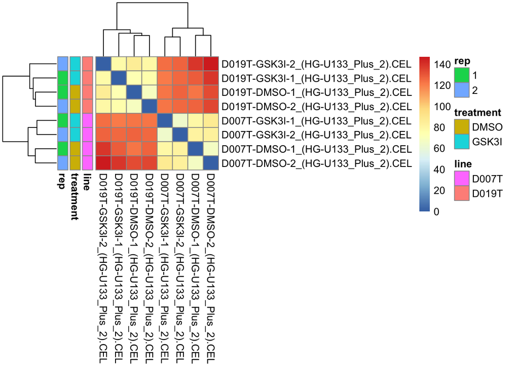

```r
## generate heatmap annotation
hm_anno <- sample_info %>%
  mutate_all(as.factor) %>%
  as.data.frame() %>% column_to_rownames('names')

## visualize distance matrix
pheatmap(as.matrix(dist(t(expr_mat))),
         annotation_row = hm_anno)
```

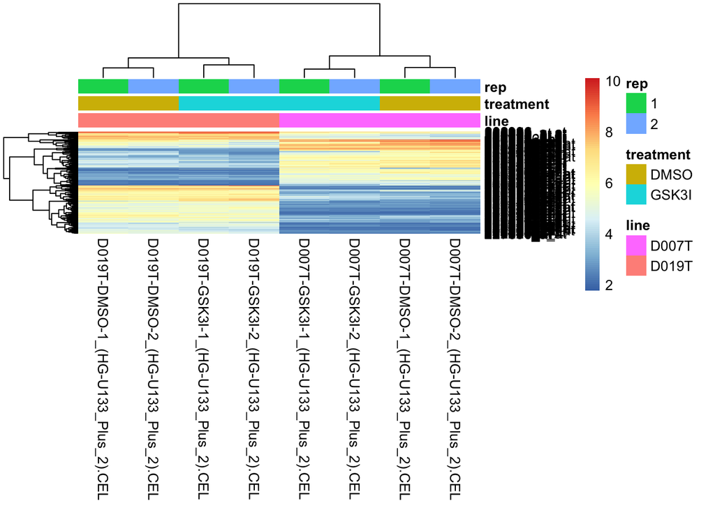

```r
## visualize most variable probes
pheatmap(expr_mat[order(apply(expr_mat, 1, sd), decreasing = T)[1:500],],
         annotation_col = hm_anno)
```

The samples cluster by line which is expected. For both lines we see a clustering by treatment which is also what we expect.

# Differential gene expression

```r
## model matrices
identical(colnames(expr_mat), sample_info$names)
mm <- model.matrix(~line + treatment, data = sample_info)
mm2 <- model.matrix(~0 + group, # no intercept
                    data = mutate(sample_info, group = paste(line, treatment, sep='_')))

## fit models and compute model coefficients
fit <- eBayes(lmFit(expr_mat, mm))
fit2 <- lmFit(expr_mat, mm2)
contr <- makeContrasts(groupD007T_GSK3I-groupD007T_DMSO,
                       groupD019T_GSK3I-groupD019T_DMSO,
                       levels = mm2)
fit2_contr <- contrasts.fit(fit2, contr)
fit2_contr <- eBayes(fit2_contr)

## extract results and annotate gene symbols
limma_results <- function(obj, coef){
  topTable(obj, coef = coef, n = Inf) %>%
  as_tibble(rownames = 'probe') %>%
  left_join(probe_anno)
}

## consistent dyregulation across both lines
res_gsk <- limma_results(fit, coef = 'treatmentGSK3I')

## line-specific effects
res_gsk7 <- limma_results(fit2_contr, coef = colnames(coef(fit2_contr))[1])
res_gsk19 <- limma_results(fit2_contr, coef = colnames(coef(fit2_contr))[2])
```

We generate an expression tibble for easy plotting.

```r
expr_long <- expr_mat %>% as_tibble(rownames = 'probe') %>%
  gather(names, expr, -probe) %>%
  left_join(sample_info) %>%
  left_join(probe_anno)
```

We plot a number of hits to validate the DGE testing.

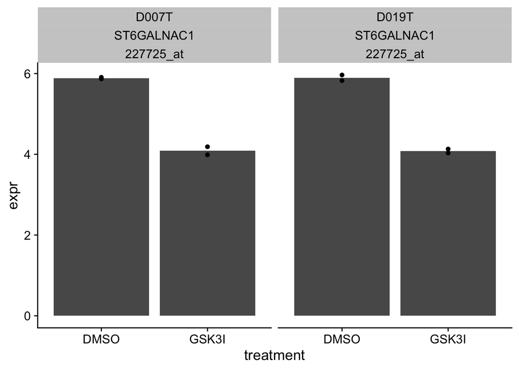

```r
## best consistent hit in both lines
expr_long %>% filter(probe == res_gsk$probe[1]) %>%
  ggplot(aes(treatment, expr)) +
  stat_summary(geom = 'bar', fun = 'mean') +
  geom_point() +
  facet_wrap(~line + symbol + probe)
```

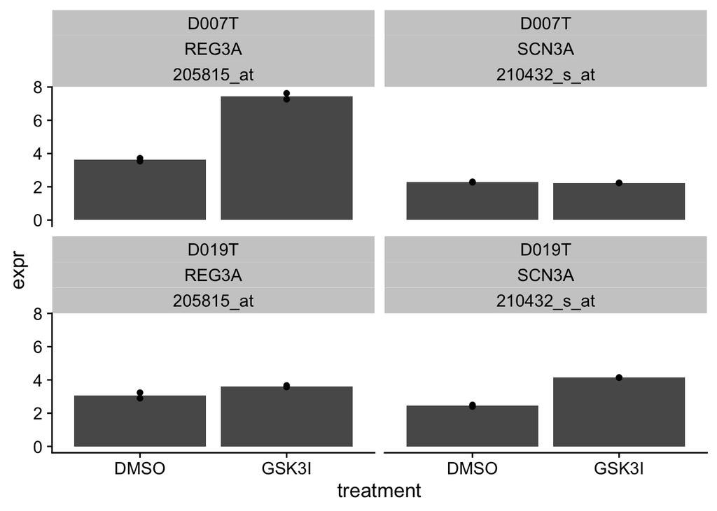

```r
## best hits in 7 and 19 respectively
expr_long %>% filter(probe %in% c(res_gsk7$probe[1], res_gsk19$probe[1])) %>%
  ggplot(aes(treatment, expr)) +
  stat_summary(geom = 'bar', fun = 'mean') +
  geom_point() +
  facet_wrap(~line + symbol + probe, scales =)
```

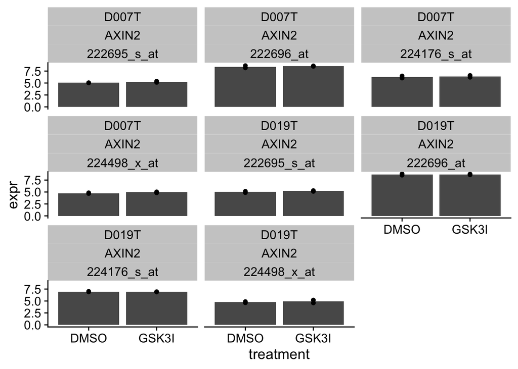

```r
## what about axin2?
expr_long %>% filter(symbol %in% c('AXIN2')) %>%
  ggplot(aes(treatment, expr)) +
  stat_summary(geom = 'bar', fun = 'mean') +
  geom_point() +
  facet_wrap(~line + symbol + probe, scales =)
```

This looks good. There is no difference between AXIN2 levels indicating that the GSK3 inhibition does not affect Wnt signaling in these lines. This is likely due to APC mutations. How many DGE do we get for each comparison?

```r
print(paste('Both lines:', nrow(res_gsk %>% filter(adj.P.Val < 0.05))))
print(paste('D007T:', nrow(res_gsk7 %>% filter(adj.P.Val < 0.05))))
print(paste('D019T:', nrow(res_gsk7 %>% filter(adj.P.Val < 0.05))))
```

# Gene set enrichment

Since there was decent signal in the combined DGE test and the GSK3 inhibitor phenotype is visible in both lines we focus on the results that are consistent in both lines for gene set enrichment analyses.

## Gene Ontology

We use the clusterProfiler + fgsea packages to perform a ranked gene set enrichment analysis in order to identify differentially expressed pathways.

```r
## select strongest probe for each entrez id
res_filtered <- res_gsk %>% inner_join(probe_anno) %>%
  group_by(entrez) %>% top_n(1, -P.Value) %>% ungroup()

## create ranked list for enrichment
ranks <- setNames(res_filtered$t, as.character(res_filtered$entrez))
ranks <- sort(ranks, decreasing = T)

## GO term enrichment (biological process)
gse_go <- gseGO(
  geneList = ranks,
  OrgDb = org.Hs.eg.db,
  ont = 'BP',
  nPerm = 1e5,
  minGSSize = 100,
  maxGSSize = 500
)
```

We can generate a network plot using clusterProfiler in order to get an overview of the results.

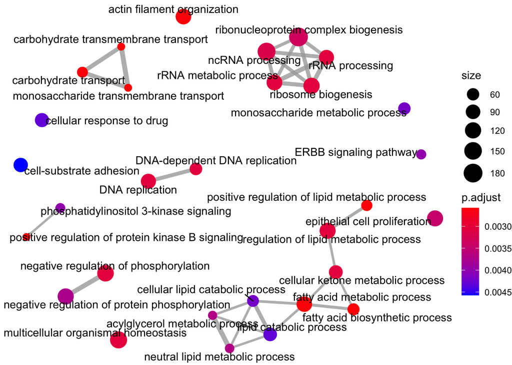

```r
emapplot(gse_go)
```

An upregulation of ribosome biogenesis might indicate a mode of action via mTOR. The link between GSK3 and TSC is known and both a highly correlated in the DepMap CRISPR data.

## Reactome

We do the same for Reactome instead of GO terms. A convenience function for enrichment against Reactome is implemented in the ‘ReactomePA’ package. Conceptually this function works the same way as the clusterProfiler functions.

```r
## Reactome enrichment analysis
gse_reactome <- gsePathway(
  geneList = ranks,
  organism = 'human',
  nPerm = 1e5,
  minGSSize = 100,
  maxGSSize = 500
)
```

Again we plot an enrichment map to visualize the results.

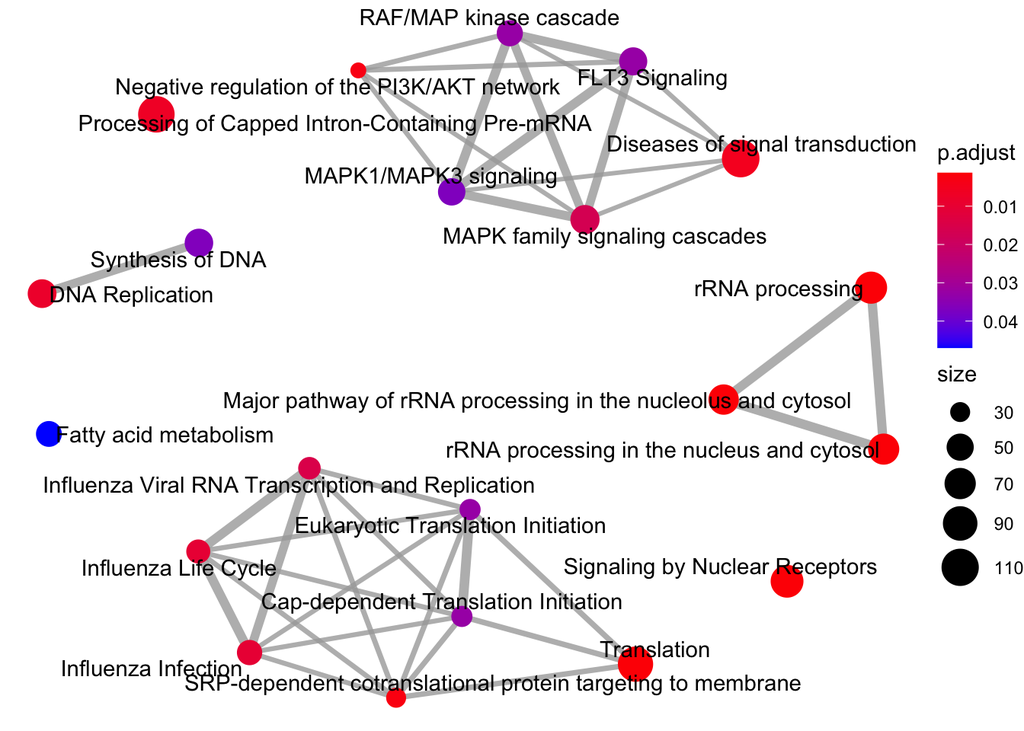

```r
emapplot(gse_reactome)
```

## Intestinal crypt signatures

We perform GSEA for the humanized intestinal crypt signatures published in Merloz-Suarez et al (Cell Stem Cell, 2011).

```r
## parse signatures and make list
intestinal_sig <- readxl::read_excel(here('../../data/gene_expression/merloz-suarez_sigantures.xls'),
                                     sheet = 1, skip = 4) %>% .[,1:4] %>%
  gather(signature, symbol) %>% drop_na() %>%
  mutate(symbol = gsub('\\*', '', symbol))

## run gsea with clusterprofiler
res_symbol <- res_gsk %>%
  group_by(symbol) %>% arrange(P.Value) %>% slice(1) %>% ungroup()
ranks_symbol <- sort(setNames(res_symbol$t, res_symbol$symbol), decreasing = T)

gse_sig <- GSEA(
  geneList = ranks_symbol,
  TERM2GENE = intestinal_sig,
  nPerm = 1e5,
  minGSSize = 1,
  maxGSSize = 1000,
  pvalueCutoff = 1
)

## output as tibble
gse_sig_tbl <- as_tibble(gse_sig)
```

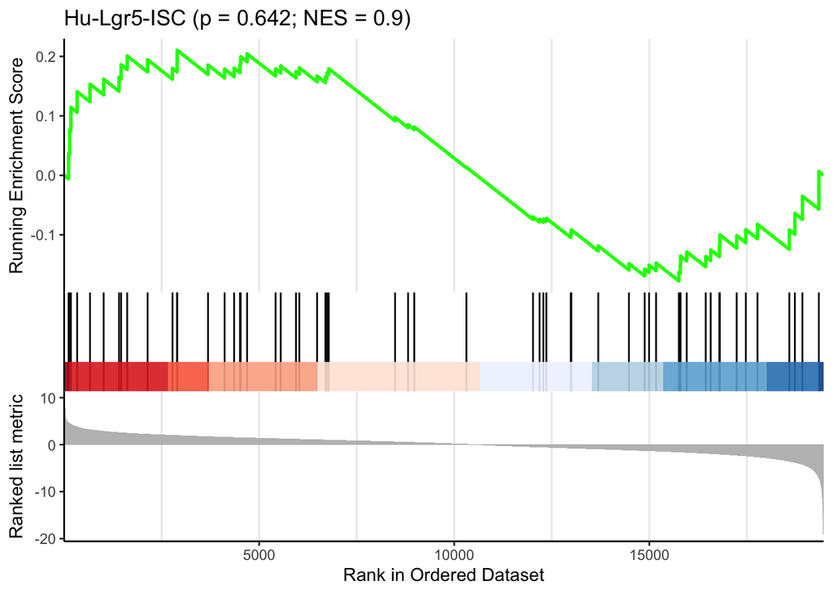

```r
## lgr5 signature
gseaplot2(
  gse_sig, geneSetID = gse_sig$ID[4],
  title = paste0(gse_sig$ID[4],
                ' (p = ', round(gse_sig_tbl$pvalue[4], 3),
                '; NES = ', round(gse_sig_tbl$NES[4], 2), ')')
)
```

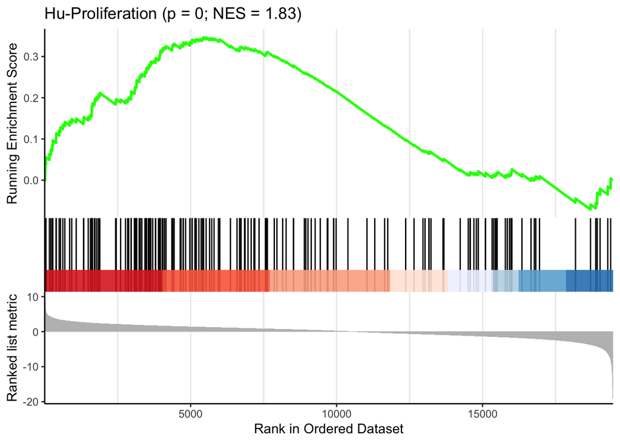

```r
## proliferation
gseaplot2(
  gse_sig, geneSetID = gse_sig$ID[1],
  title = paste0(gse_sig$ID[1],
                ' (p = ', round(gse_sig_tbl$pvalue[1], 3),
                '; NES = ', round(gse_sig_tbl$NES[1], 2), ')')
)
```

There is a strong upregulation of the proliferation signature, but both stemness signatures remain unchanged.